# Tugas Pertemuan 6

# Input Data

```r
data <- read_xlsx("/Users/mrkahar/Downloads/JKSE_Close_Weekly.xlsx")

data1 <- data[776:1033, ]
data1
```

```
## # A tibble: 258 × 2
##    Date                Close
##    <dttm>              <dbl>
##  1 2020-08-24 00:00:00 5347.
##  2 2020-08-31 00:00:00 5240.
##  3 2020-09-07 00:00:00 5017.
##  4 2020-09-14 00:00:00 5059.
##  5 2020-09-21 00:00:00 4946.
##  6 2020-09-28 00:00:00 4927.
##  7 2020-10-05 00:00:00 5054.
##  8 2020-10-12 00:00:00 5103.
##  9 2020-10-19 00:00:00 5112.
## 10 2020-10-26 00:00:00 5128.
## # ℹ 248 more rows
```

# Split Data

## Data Training

```r
dtgab1 <- data1[1:206, ]
ts_train <- ts(dtgab1$Close)
mean(dtgab1$Close)
```

```
## [1] 6648.181
```

```r
var(dtgab1$Close)
```

```
## [1] 317463.9
```

### Plot Time Series

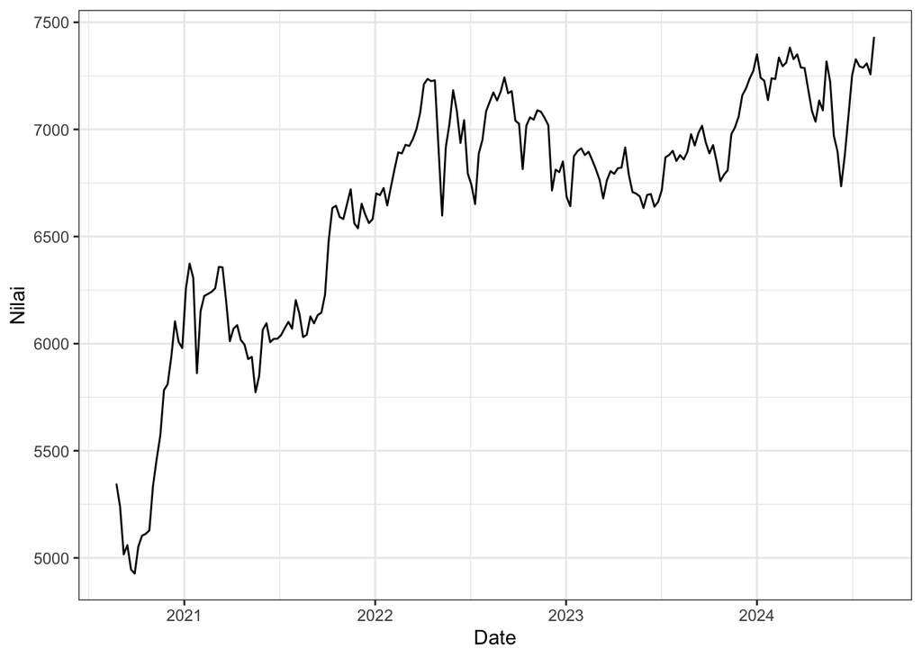

```r
plot2 <- ggplot(dtgab1, aes(x = Date, y = Close)) +
  geom_line() +
  theme_bw() +
  xlab("Date") +
  ylab("Nilai")

plot2
```

### Plot ACF

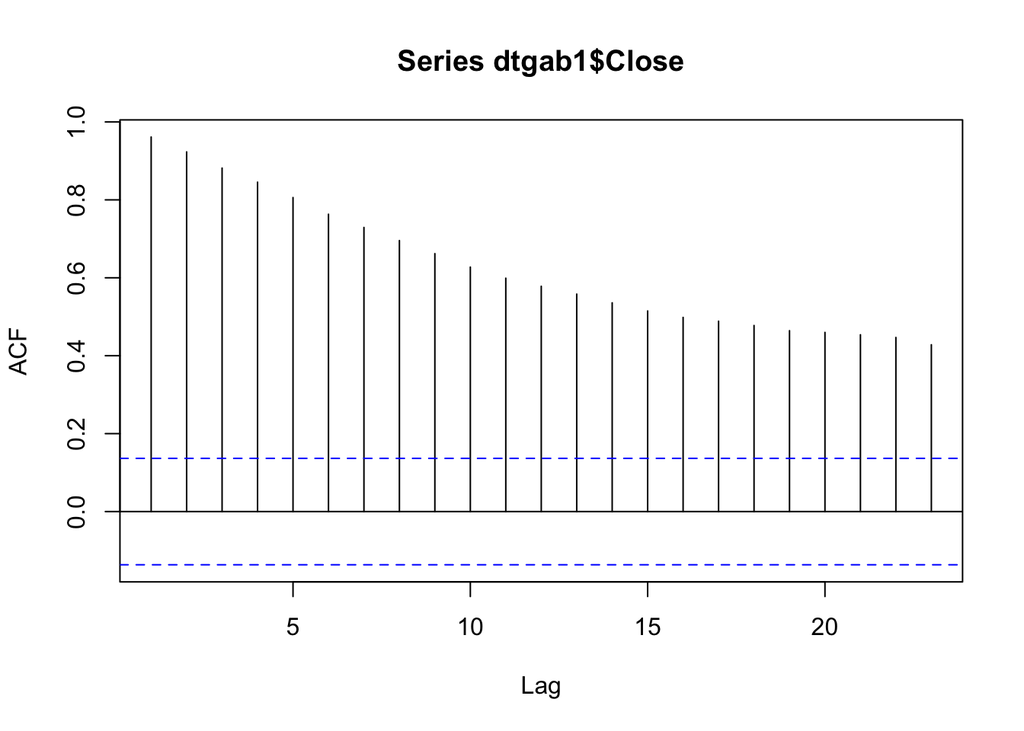

```r
acf(dtgab1$Close)
```

Berdasarkan plot ACF, terlihat bahwa plot ACF pada data training menurun secara perlahan (tails off slowly) pada banyak lag yang mengindikasikan kuat bahwa data **tidak stasioner dalam rataan**.

### Uji ADF

H0 : Data tidak stasioner dalam rataan

H1 : Data stasioner dalam rataan

```r
adf.test(dtgab1$Close)
```

```
## Augmented Dickey-Fuller Test
## alternative: stationary
##
## Type 1: no drift no trend
##      lag  ADF p.value
## [1,]   0 1.09   0.925
## [2,]   1 1.16   0.934
## [3,]   2 1.34   0.954
## [4,]   3 1.47   0.964
## [5,]   4 1.54   0.969
## Type 2: with drift no trend
##      lag   ADF p.value
## [1,]   0 -2.07  0.3025
## [2,]   1 -2.25  0.2306
## [3,]   2 -2.65  0.0886
## [4,]   3 -2.61  0.0958
## [5,]   4 -2.96  0.0425
## Type 3: with drift and trend
##      lag   ADF p.value
## [1,]   0 -2.81  0.2362
## [2,]   1 -2.94  0.1832
## [3,]   2 -3.20  0.0885
## [4,]   3 -3.01  0.1516
## [5,]   4 -3.36  0.0616
## ----
## Note: in fact, p.value = 0.01 means p.value <= 0.01
```

### Plot Box-Cox

```r
index <- seq(1:206)
bc = boxcox(dtgab1$Close+1~index,
             lambda = seq(3,5,by=1))
```

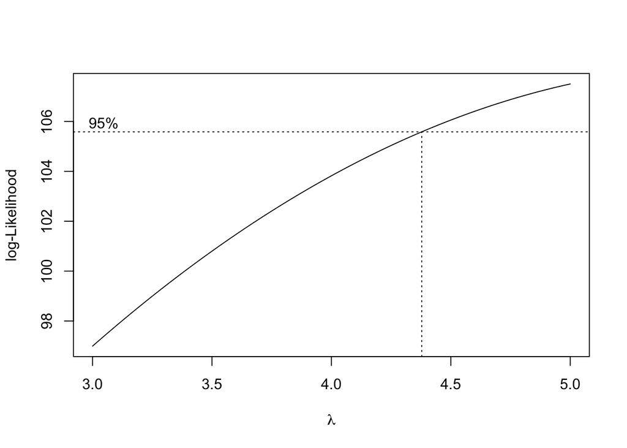

```r
#Nilai Rounded Lambda
lambda <- bc$x[which.max(bc$y)]
lambda
```

```
## [1] 5
```

```r
# Selang kepercayaan 95% untuk lambda
ci_lambda <- bc$x[bc$y > max(bc$y) - 0.5 * qchisq(0.95, 1)]

# Batas bawah dan batas atas
ci_lower <- min(ci_lambda)
ci_upper <- max(ci_lambda)

c(Batas_Bawah = ci_lower, Batas_Atas = ci_upper)
```

```
## Batas_Bawah  Batas_Atas
##    4.393939    5.000000
```

Hasil uji Box–Cox menunjukkan bahwa nilai λ optimum adalah 5 dengan interval kepercayaan 95% sebesar (4.394-5.000). Karena selang tersebut tidak memuat nilai λ = 1, maka dapat disimpulkan bahwa data **tidak stasioner dalam ragam** sehingga diperlukan penanganan.

### Differencing

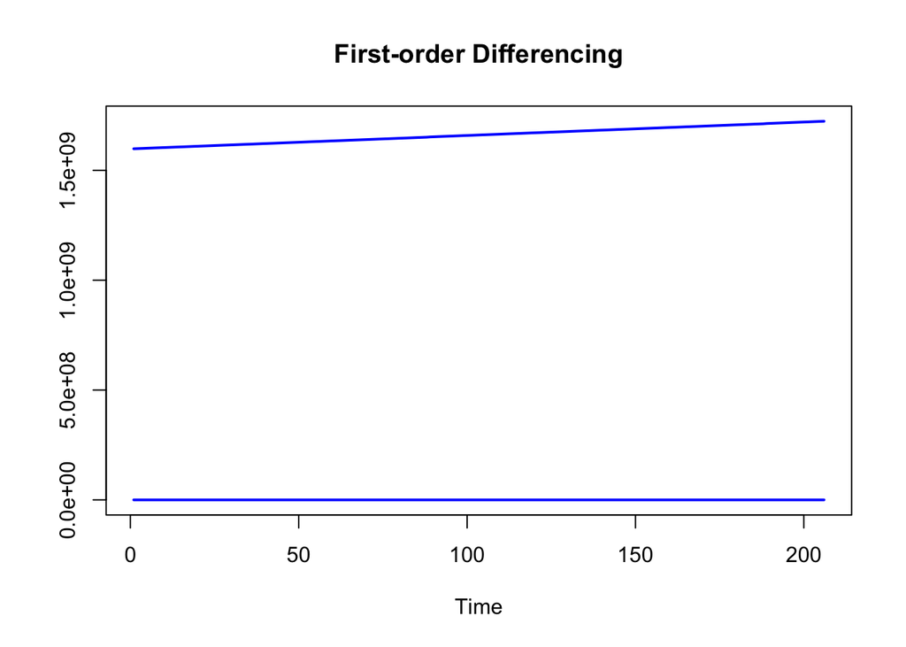

```r
diff1 <- diff(dtgab1$Close, differences = 1)

# Plot hasil differencing
ts.plot(dtgab1,
        main = "First-order Differencing",
        col = "blue", lwd = 2)
```

#### Uji ADF Setelah Differencing

H0 : Data tidak stasioner dalam rataan

H1 : Data stasioner dalam rataan

```r
tseries::adf.test(diff1)
```

```
##
##  Augmented Dickey-Fuller Test
##
## data:  diff1
## Dickey-Fuller = -7.0151, Lag order = 5, p-value = 0.01
## alternative hypothesis: stationary
```

Berdasarkan uji ADF tersebut, didapat p-value < 0.01 yang lebih kecil dari taraf nyata 5% dan menandakan bahwa data hasil differencing pertama sudah **stasioner dalam rataan.**

#### Plot Box-Cox Setelah Differencing

```r
index <- 1:length(diff1)
bcc = boxcox(diff1 - min(diff1) + 1~index,
             lambda = seq(-1,5,by=1))
```

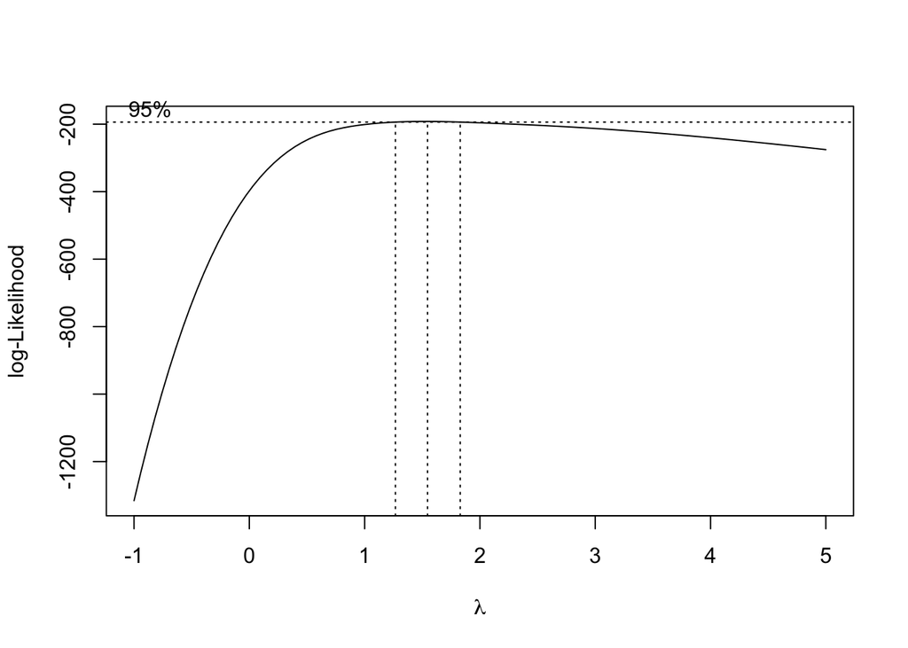

```r
#Nilai Rounded Lambda
lambdaa <- bcc$x[which.max(bcc$y)]
lambdaa
```

```
## [1] 1.545455
```

```r
# Selang kepercayaan 95% untuk lambda
ci_lambdaa <- bcc$x[bc$y > max(bcc$y) - 0.5 * qchisq(0.95, 1)]

# Batas bawah dan batas atas
ci_lowerr <- min(ci_lambdaa)
ci_upperr <- max(ci_lambdaa)

c(Batas_Bawah = ci_lowerr, Batas_Atas = ci_upperr)
```

```
## Batas_Bawah  Batas_Atas
##          -1           5
```

## Data Testing

```r
dtgab2 <- data1[207:258, ]
ts_test  <- ts(dtgab2$Close)
mean(dtgab2$Close)
```

```
## [1] 7152.213
```

```r
var(dtgab2$Close)
```

```
## [1] 190842
```

### Plot Time Series

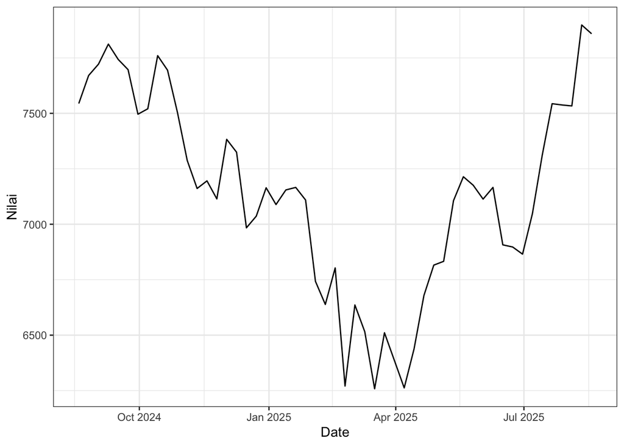

```r
plot1 <- dtgab2 |>
  ggplot(aes(x = Date, y = Close)) +
  geom_line() +
  theme_bw() +
  xlab("Date") +
  ylab("Nilai")

plot1
```

Berdasarkan plot time series tersebut, terlihat bahwa data testing **tidak stasioner dalam rataan dan ragam**, ditandai dengan adanya trend pada data serta perbedaan lebar pita pada plot.

### Plot ACF

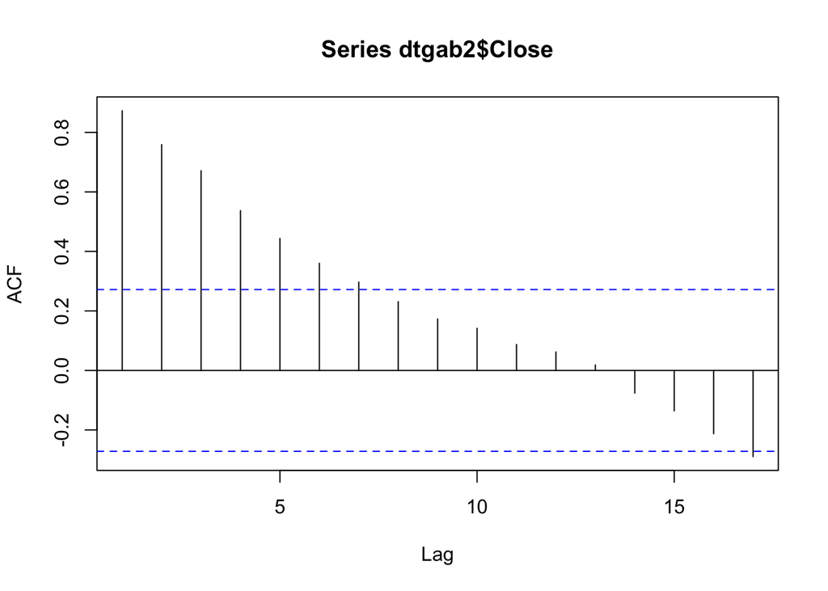

```r
acf(dtgab2$Close)
```

Berdasarkan plot ACF, terlihat bahwa plot ACF pada data testing menurun secara perlahan (tails off slowly) yang menandakan data **tidak stasioner dalam rataan.**

### Uji ADF

H0 : Data tidak stasioner dalam rataan

H1 : Data stasioner dalam rataan

```r
adf.test(dtgab2$Close)
```

```
## Augmented Dickey-Fuller Test
## alternative: stationary
##
## Type 1: no drift no trend
##      lag     ADF p.value
## [1,]   0  0.1548   0.684
## [2,]   1  0.1002   0.669
## [3,]   2  0.0514   0.655
## [4,]   3 -0.0421   0.628
## Type 2: with drift no trend
##      lag   ADF p.value
## [1,]   0 -1.28   0.596
## [2,]   1 -1.18   0.630
## [3,]   2 -1.22   0.616
## [4,]   3 -1.75   0.424
## Type 3: with drift and trend
##      lag    ADF p.value
## [1,]   0 -0.801   0.956
## [2,]   1 -0.422   0.982
## [3,]   2 -0.295   0.988
## [4,]   3 -0.833   0.953
## ----
## Note: in fact, p.value = 0.01 means p.value <= 0.01
```

Berdasarkan uji ADF tersebut, didapat p-value sebesar 0.9532 yang lebih besar dari taraf nyata 5% dan menandakan bahwa data **tidak stasioner dalam rataan**. Hal ini sesuai dengan hasil eksplorasi menggunakan plot time series dan plot ACF.

### Plot Box-Cox

```r
index <- 1:nrow(dtgab2)
bc2 = boxcox(dtgab2$Close+1~index,
             lambda = seq(3,5,by=1))
```

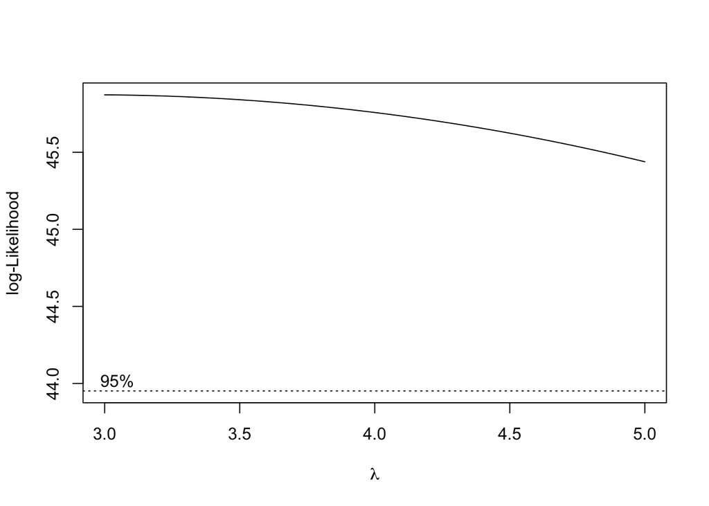

```r
#Nilai Rounded Lambda
lambda <- bc2$x[which.max(bc2$y)]
lambda
```

```
## [1] 3
```

```r
# Selang kepercayaan 95% untuk lambda
ci_lambda2 <- bc2$x[bc2$y > max(bc2$y) - 0.5 * qchisq(0.95, 1)]

# Batas bawah dan batas atas
ci_lower2 <- min(ci_lambda2)
ci_upper2 <- max(ci_lambda2)

c(Batas_Bawah = ci_lower2, Batas_Atas = ci_upper2)
```

```
## Batas_Bawah  Batas_Atas
##           3           5
```

# Spesifikasi Model

## Plot ACF

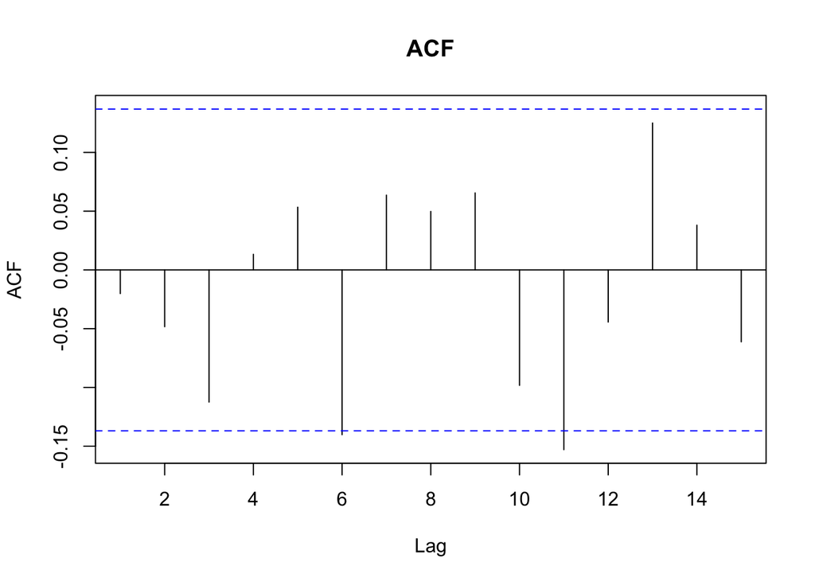

```r
acf(diff1, main="ACF", lag.max=15)
```

Berdasarkan plot tersebut, terlihat bahwa plot ACF cenderung cuts off pada lag ke 6, sehingga jika plot PACF dianggap tails of, maka model tentatifnya adalah **ARIMA(0,1,6).**

## Plot PACF

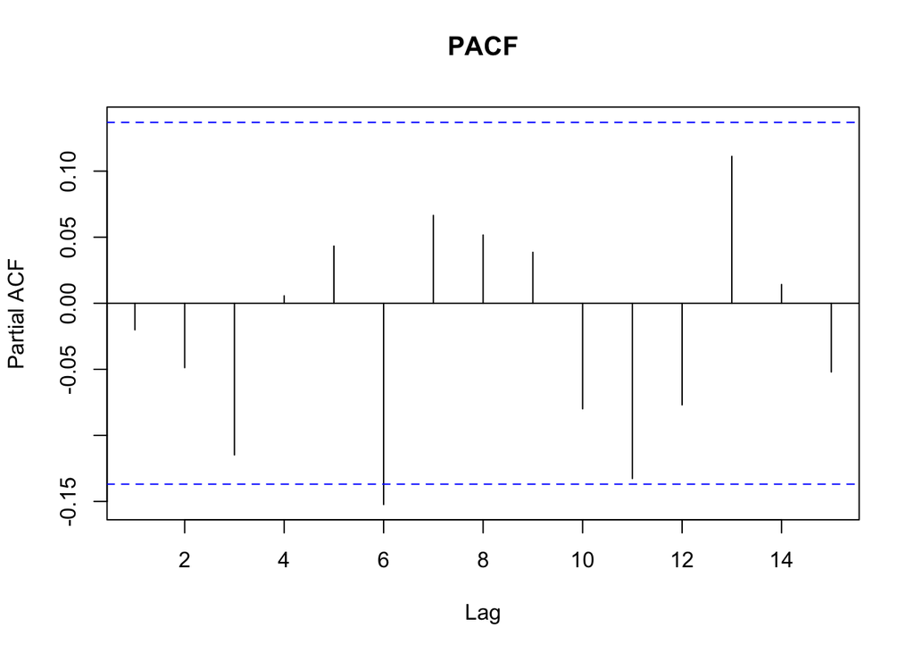

```r
pacf(diff1, main="PACF", lag.max=15)
```

Berdasarkan plot tersebut, terlihat bahwa plot PACF cenderung cuts off pada lag ke 6, sehingga jika plot ACF dianggap tails of, maka model tentatifnya adalah **ARIMA(6,1,0).**

## Plot EACF

```r
eacf(diff1)
```

```
## AR/MA
##   0 1 2 3 4 5 6 7 8 9 10 11 12 13
## 0 o o o o o o o o o o x  o  o  o
## 1 x o o o o o o o o o o  o  o  o
## 2 x o o o o o o o o o o  o  o  o
## 3 o x x o o o o o o o o  o  o  o
## 4 o o x x o o o o o o o  o  o  o
## 5 x o x o o o o o o o o  o  o  o
## 6 x x x o o o o o o o o  o  o  o
## 7 x o x o o o o o o o o  o  o  o
```

Berdasarkan plot EACF, dapat diambil beberapa model dengan melihat ujung segitiga yang terbentuk, antara lain **ARIMA(0,1,1), ARIMA(1,1,1), dan ARIMA(1,1,2).**

# Pendugaan Parameter

```r
model1=Arima(ts_train, order=c(0,1,6),method="ML")
summary(model1)
```

```
## Series: ts_train
## ARIMA(0,1,6)
##
## Coefficients:
##          ma1      ma2      ma3     ma4     ma5      ma6
##       0.0143  -0.0311  -0.1203  0.0140  0.0540  -0.1249
## s.e.  0.0711   0.0752   0.0728  0.0711  0.0834   0.0809
##
## sigma^2 = 13205:  log likelihood = -1260.48
## AIC=2534.96   AICc=2535.53   BIC=2558.22
##
## Training set error measures:
##                    ME     RMSE      MAE       MPE     MAPE     MASE        ACF1
## Training set 12.37546 112.9454 79.89462 0.1778674 1.223992 0.987776 -0.02383482
```

```r
lmtest::coeftest(model1)
```

```
##
## z test of coefficients:
##
##      Estimate Std. Error z value Pr(>|z|)
## ma1  0.014292   0.071091  0.2010  0.84067
## ma2 -0.031064   0.075227 -0.4129  0.67965
## ma3 -0.120312   0.072793 -1.6528  0.09837 .
## ma4  0.014009   0.071096  0.1970  0.84380
## ma5  0.053979   0.083373  0.6474  0.51735
## ma6 -0.124898   0.080859 -1.5446  0.12243
## ---
## Signif. codes:  0 '***' 0.001 '**' 0.01 '*' 0.05 '.' 0.1 ' ' 1
```

```r
model2=Arima(ts_train, order=c(6,1,0),method="ML")
summary(model2)
```

```
## Series: ts_train
## ARIMA(6,1,0)
##
## Coefficients:
##           ar1      ar2      ar3     ar4     ar5      ar6
##       -0.0083  -0.0302  -0.1203  0.0130  0.0525  -0.1443
## s.e.   0.0695   0.0700   0.0700  0.0698  0.0697   0.0699
##
## sigma^2 = 13171:  log likelihood = -1260.22
## AIC=2534.44   AICc=2535.01   BIC=2557.7
##
## Training set error measures:
##                    ME     RMSE      MAE       MPE     MAPE      MASE
## Training set 12.38801 112.7998 79.96841 0.1779731 1.225186 0.9886884
##                       ACF1
## Training set -0.0008623321
```

```r
lmtest::coeftest(model2)
```

```
##
## z test of coefficients:
##
##       Estimate Std. Error z value Pr(>|z|)
## ar1 -0.0083208  0.0695231 -0.1197  0.90473
## ar2 -0.0302081  0.0700026 -0.4315  0.66608
## ar3 -0.1202814  0.0700286 -1.7176  0.08587 .
## ar4  0.0129786  0.0698367  0.1858  0.85257
## ar5  0.0525307  0.0696557  0.7541  0.45076
## ar6 -0.1443058  0.0698922 -2.0647  0.03895 *
## ---
## Signif. codes:  0 '***' 0.001 '**' 0.01 '*' 0.05 '.' 0.1 ' ' 1
```

```r
model3=Arima(ts_train, order=c(0,1,1),method="ML")
summary(model3)
```

```
## Series: ts_train
## ARIMA(0,1,1)
##
## Coefficients:
##           ma1
##       -0.0136
## s.e.   0.0735
##
## sigma^2 = 13339:  log likelihood = -1263.97
## AIC=2531.94   AICc=2532   BIC=2538.59
##
## Training set error measures:
##                    ME     RMSE      MAE       MPE    MAPE      MASE
## Training set 10.27779 114.9332 80.65671 0.1465042 1.23266 0.9971981
##                      ACF1
## Training set -0.007053862
```

```r
lmtest::coeftest(model3)
```

```
##
## z test of coefficients:
##
##      Estimate Std. Error z value Pr(>|z|)
## ma1 -0.013645   0.073534 -0.1856   0.8528
```

```r
model4=Arima(ts_train, order=c(1,1,1),method="ML")
summary(model4)
```

```
## Series: ts_train
## ARIMA(1,1,1)
##
## Coefficients:
##          ar1      ma1
##       0.8350  -0.8726
## s.e.  0.2729   0.2434
##
## sigma^2 = 13345:  log likelihood = -1263.52
## AIC=2533.04   AICc=2533.16   BIC=2543.01
##
## Training set error measures:
##                    ME    RMSE      MAE       MPE     MAPE     MASE       ACF1
## Training set 12.82353 114.676 80.99749 0.1840802 1.237776 1.001411 0.00795903
```

```r
lmtest::coeftest(model4)
```

```
##
## z test of coefficients:
##
##     Estimate Std. Error z value  Pr(>|z|)
## ar1  0.83504    0.27286  3.0603 0.0022112 **
## ma1 -0.87260    0.24335 -3.5857 0.0003362 ***
## ---
## Signif. codes:  0 '***' 0.001 '**' 0.01 '*' 0.05 '.' 0.1 ' ' 1
```

```r
model5=Arima(ts_train, order=c(1,1,2),method="ML")
summary(model5)
```

```
## Series: ts_train
## ARIMA(1,1,2)
##
## Coefficients:
##          ar1      ma1      ma2
##       0.5467  -0.5677  -0.0489
## s.e.  0.5509   0.5478   0.0739
##
## sigma^2 = 13396:  log likelihood = -1263.4
## AIC=2534.81   AICc=2535.01   BIC=2548.1
##
## Training set error measures:
##                    ME     RMSE      MAE       MPE    MAPE      MASE
## Training set 11.86524 114.6107 80.71021 0.1696991 1.23367 0.9978595
##                      ACF1
## Training set -0.007922941
```

```r
lmtest::coeftest(model5)
```

```
##
## z test of coefficients:
##
##      Estimate Std. Error z value Pr(>|z|)
## ar1  0.546715   0.550939  0.9923   0.3210
## ma1 -0.567702   0.547775 -1.0364   0.3000
## ma2 -0.048881   0.073915 -0.6613   0.5084
```

```r
hasil_model <- data.frame(
  Model = c("ARIMA(0,1,6)",
            "ARIMA(6,1,0)",
            "ARIMA(0,1,1)",
            "ARIMA(1,1,1)",
            "ARIMA(1,1,2)"),
  AIC = c(
    AIC(model1),
    AIC(model2),
    AIC(model3),
    AIC(model4),
    AIC(model5)
  ),
  BIC = c(
    BIC(model1),
    BIC(model2),
    BIC(model3),
    BIC(model4),
    BIC(model5)
  )
)

hasil_model
```

```
##          Model      AIC      BIC
## 1 ARIMA(0,1,6) 2534.959 2558.220
## 2 ARIMA(6,1,0) 2534.443 2557.704
## 3 ARIMA(0,1,1) 2531.944 2538.590
## 4 ARIMA(1,1,1) 2533.045 2543.014
## 5 ARIMA(1,1,2) 2534.807 2548.099
```

Berdasarkan hasil perbandingan, model ARIMA(0,1,1) memiliki nilai AIC dan BIC terkecil. Namun, karena seluruh parameter pada model ARIMA(1,1,1) terbukti signifikan dan perbedaan nilai AIC serta BIC antar model relatif kecil, maka model **ARIMA(1,1,1)** dipilih sebagai model yang lebih tepat.

# Analisis Sisaan

## Eksplorasi Sisaan

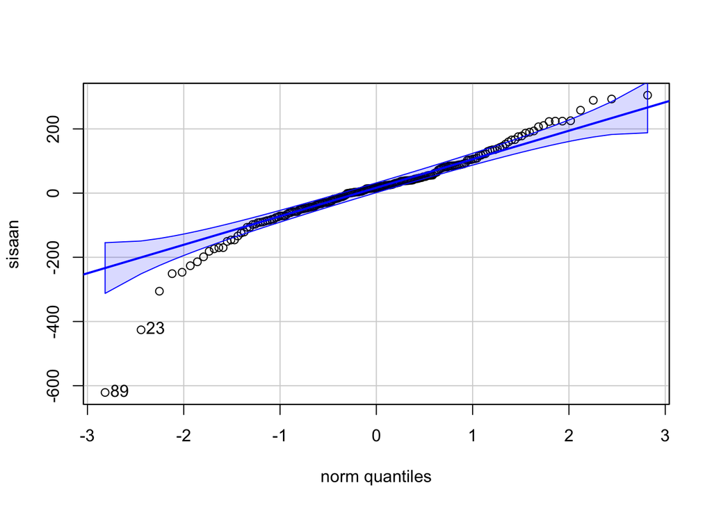

```
## [1] 89 23
```

```r
sisaan <- model4$residuals

car::qqPlot(sisaan)
```

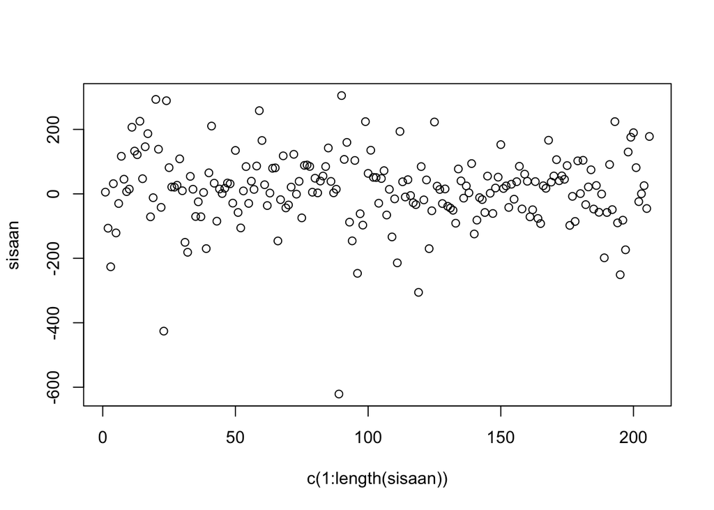

```r
plot(c(1:length(sisaan)),sisaan)
```

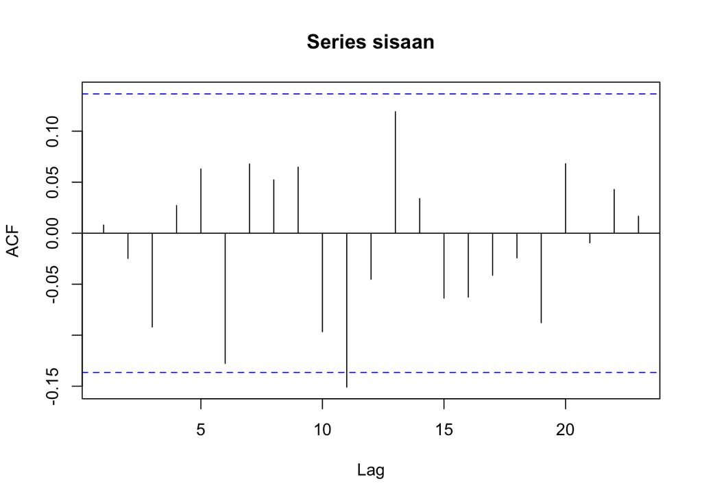

```r
acf(sisaan)
```

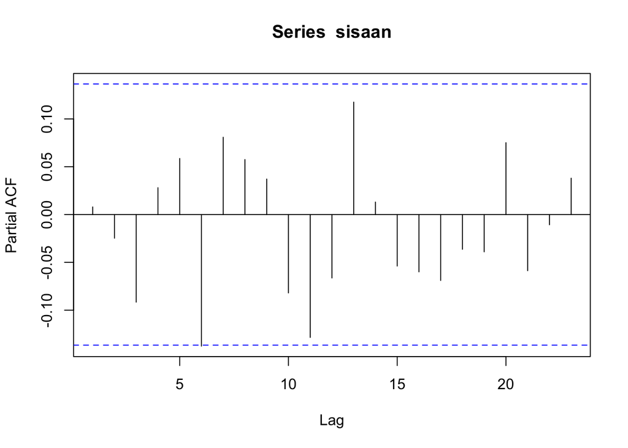

```r
pacf(sisaan)
```

Berdasarkan plot kuantil-kuantil normal, terlihat bahwa titik-titik sisaan cenderung tidak mengikuti garis diagonal, sehingga dapat dikatakan **sisaan tidak sepenuhnya menyebar mendekati normal**. Plot sebaran sisaan juga menunjukkan lebar pita yang tidak seragam, menandakan bahwa **ragam sisaan bersifat heterogen.** Selain itu, pada plot ACF dan PACF sisaan model ARIMA(1,1,1) terlihat adanya nilai yang signifikan pada lag ke-11 dan 6, sehingga **sisaan belum sepenuhnya saling bebas.** Kondisi ini akan dikonfirmasi lebih lanjut melalui uji formal.

## Uji Formal

**H0: Sisaan menyebar normal**

**H1: Sisaan tidak menyebar normal**

```r
#1) Sisaan Menyebar Normal
ks.test(sisaan,"pnorm")
```

```
##
##  Asymptotic one-sample Kolmogorov-Smirnov test
##
## data:  sisaan
## D = 0.58627, p-value < 2.2e-16
## alternative hypothesis: two-sided
```

Berdasarkan uji KS tersebut, didapat p-value sebesar < 2.2e-16 yang kurang dari taraf nyata 5% sehingga tolak H0 dan menandakan bahwa sisaan tidak menyebar normal. Hal ini sesuai dengan hasil eksplorasi menggunakan plot kuantil-kuantil normal.

**H0: Sisaan saling bebas**

**H1: Sisaan tidak saling bebas**

```r
#2) Sisaan saling bebas/tidak ada autokorelasi
Box.test(sisaan, type = "Ljung")
```

```
##
##  Box-Ljung test
##
## data:  sisaan
## X-squared = 0.01324, df = 1, p-value = 0.9084
```

Berdasarkan uji Ljung-Box tersebut, didapat p-value sebesar 0.9084 yang lebih besar dari taraf nyata 5% sehingga gagal tolak H0 dan menandakan bahwa sisaan saling bebas. Hal ini berbeda dengan eksplorasi dengan plot ACF dan PACF.

**H0: Ragam sisaan homogen**

**H1: Ragam sisaan tidak homogen**

```r
#3) Sisaan homogen
Box.test((sisaan)^2, type = "Ljung")
```

```
##
##  Box-Ljung test
##
## data:  (sisaan)^2
## X-squared = 5.6283, df = 1, p-value = 0.01767
```

Berdasarkan uji Ljung-Box terhadap sisaan kuadrat tersebut, didapat p-value sebesar 0.0177 yang kurang dari taraf nyata 5% sehingga tolak H0 dan menandakan bahwa ragam sisaan tidak homogen. Hal ini sesuai dengan hasil eksplorasi menggunakan plot sebaran sisaan.

**H0: Nilai tengah sisaan sama dengan nol**

**H1: Nilai tengah sisaan tidak sama dengan nol**

```r
#4) Nilai tengah sisaan sama dengan nol
t.test(sisaan, mu = 0, conf.level = 0.95)
```

```
##
##  One Sample t-test
##
## data:  sisaan
## t = 1.6112, df = 205, p-value = 0.1087
## alternative hypothesis: true mean is not equal to 0
## 95 percent confidence interval:
##  -2.868631 28.515687
## sample estimates:
## mean of x
##  12.82353
```

Berdasarkan uji-ttersebut, didapat p-value sebesar 0.1087 yang lebih besar dari taraf nyata 5% sehingga gagal tolak H0 dan menandakan bahwa nilai tengah sisaan sama dengan nol. Hal ini berbeda dengan eksplorasi.

# Overfitting

Tahapan selanjutnya adalah overfitting dilakukan dengan menaikkan orde AR(p) dan MA(q) dari model ARIMA(1,1,1) Kandidat model overfitting adalah **ARIMA(2,1,1) dan ARIMA(1,1,2).**

```r
model1a=Arima(ts_train, order=c(2,1,1),method="ML")
summary(model1a)
```

```
## Series: ts_train
## ARIMA(2,1,1)
##
## Coefficients:
##          ar1      ar2      ma1
##       0.5647  -0.0560  -0.5821
## s.e.  0.4876   0.0774   0.4857
##
## sigma^2 = 13391:  log likelihood = -1263.37
## AIC=2534.74   AICc=2534.94   BIC=2548.03
##
## Training set error measures:
##                    ME     RMSE      MAE       MPE     MAPE      MASE
## Training set 11.81283 114.5911 80.67374 0.1689257 1.233149 0.9974087
##                     ACF1
## Training set -0.01175133
```

```r
lmtest::coeftest(model1a)
```

```
##
## z test of coefficients:
##
##      Estimate Std. Error z value Pr(>|z|)
## ar1  0.564746   0.487608  1.1582   0.2468
## ar2 -0.056030   0.077422 -0.7237   0.4693
## ma1 -0.582084   0.485656 -1.1986   0.2307
```

```r
model1b=Arima(ts_train, order=c(1,1,2),method="ML")
summary(model1b)
```

```
## Series: ts_train
## ARIMA(1,1,2)
##
## Coefficients:
##          ar1      ma1      ma2
##       0.5467  -0.5677  -0.0489
## s.e.  0.5509   0.5478   0.0739
##
## sigma^2 = 13396:  log likelihood = -1263.4
## AIC=2534.81   AICc=2535.01   BIC=2548.1
##
## Training set error measures:
##                    ME     RMSE      MAE       MPE    MAPE      MASE
## Training set 11.86524 114.6107 80.71021 0.1696991 1.23367 0.9978595
##                      ACF1
## Training set -0.007922941
```

```r
lmtest::coeftest(model1b)
```

```
##
## z test of coefficients:
##
##      Estimate Std. Error z value Pr(>|z|)
## ar1  0.546715   0.550939  0.9923   0.3210
## ma1 -0.567702   0.547775 -1.0364   0.3000
## ma2 -0.048881   0.073915 -0.6613   0.5084
```

```r
overfitting <- data.frame(
  Model = c("ARIMA(2,1,1)","ARIMA(1,1,1)", "ARIMA(1,1,2)"),
  AIC   = c(AIC(model1a),AIC(model4), AIC(model1b)),
  BIC   = c(BIC(model1a),BIC(model4), BIC(model1b))
)

overfitting
```

```
##          Model      AIC      BIC
## 1 ARIMA(2,1,1) 2534.738 2548.030
## 2 ARIMA(1,1,1) 2533.045 2543.014
## 3 ARIMA(1,1,2) 2534.807 2548.099
```

Berdasarkan hasil perbandingan, nilai AIC dan BIC terkecil dimiliki oleh model **ARIMA(1,1,1)** sehingga model tersebut ditetapkan sebagai model terbaik. Selanjutnya akan dilakukan peramalan dengan model terbaik.

# Peramalan

```r
ramalan <- forecast::forecast(model4, h = length(ts_test))
ramalan
```

```
##     Point Forecast    Lo 80    Hi 80    Lo 95    Hi 95
## 207       7422.932 7274.887 7570.977 7196.517 7649.348
## 208       7415.285 7209.812 7620.759 7101.041 7729.530
## 209       7408.900 7161.474 7656.326 7030.495 7787.305
## 210       7403.568 7122.203 7684.932 6973.258 7833.878
## 211       7399.115 7088.865 7709.366 6924.628 7873.603
## 212       7395.397 7059.771 7731.024 6882.100 7908.694
## 213       7392.293 7033.876 7750.709 6844.142 7940.443
## 214       7389.700 7010.479 7768.921 6809.731 7969.669
## 215       7387.535 6989.079 7785.992 6778.149 7996.922
## 216       7385.728 6969.307 7802.149 6748.866 8022.589
## 217       7384.218 6950.881 7817.555 6721.486 8046.950
## 218       7382.958 6933.584 7832.331 6695.700 8070.216
## 219       7381.905 6917.243 7846.567 6671.266 8092.545
## 220       7381.026 6901.720 7860.332 6647.991 8114.062
```

[output cut: 38 more lines]

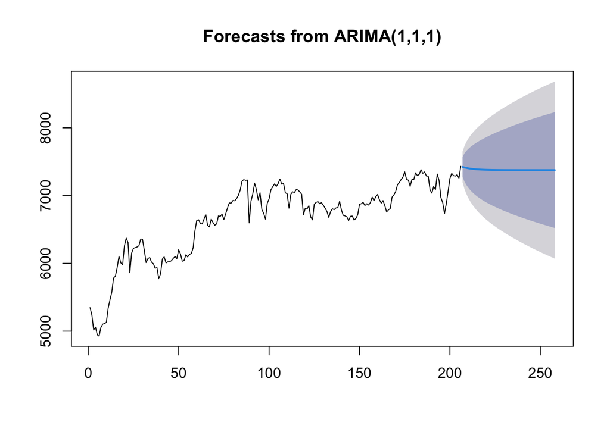

```r
data.ramalan <- ramalan$mean
plot(ramalan)
```

```r
hasil <- as.numeric(ramalan$mean)

# Bandingkan aktual vs forecast
perbandingan <- cbind(
  Aktual   = ts_test,
  Forecast = hasil
)

perbandingan
```

```
## Time Series:
## Start = 1
## End = 52
## Frequency = 1
##      Aktual Forecast
##  1 7544.298 7422.932
##  2 7670.733 7415.285
##  3 7721.846 7408.900
##  4 7812.131 7403.568
##  5 7743.004 7399.115
##  6 7696.916 7395.397
##  7 7496.091 7392.293
##  8 7520.602 7389.700
##  9 7760.060 7387.535
## 10 7694.660 7385.728
```

[output cut: 42 more lines]

```r
# Hitung akurasi
akurasi_test <- accuracy(hasil, ts_test)
akurasi_test
```

```
##                 ME     RMSE      MAE       MPE     MAPE      ACF1 Theil's U
## Test set -229.7678 485.1531 394.1137 -3.594949 5.723835 0.8706252  2.667951
```

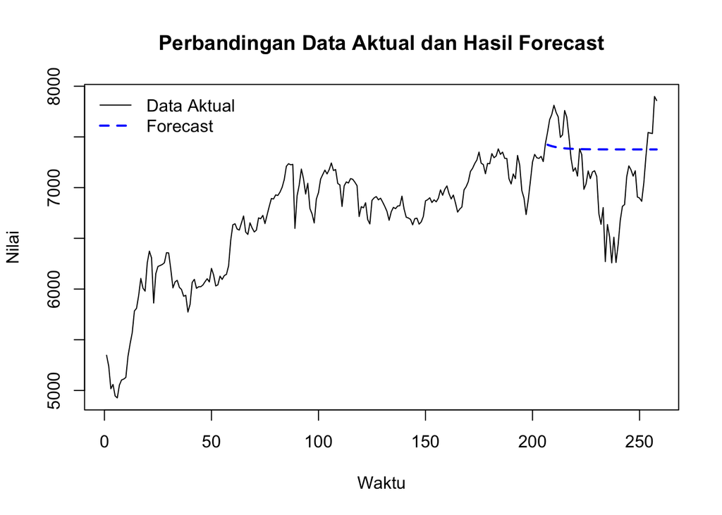

```r
# Plot data aktual (gabungan train + test)
ts.plot(c(ts_train, ts_test), col = "black", lty = 1,
        xlab = "Waktu", ylab = "Nilai",
        main = "Perbandingan Data Aktual dan Hasil Forecast")

# Garis hasil forecast
lines((length(ts_train)+1):(length(ts_train)+length(hasil)), hasil,
      col = "blue", lty = 2, lwd = 2)

# Tambahkan legenda
legend("topleft",
       legend = c("Data Aktual", "Forecast"),
       col = c("black", "blue"),
       lty = c(1, 2),
       lwd = c(1, 2),
       bty = "n")
```

Zifa Aura Rahman  
G1401231010